# Clustering Heatmap - RNA-Seq

CCDL for ALSF

*Purpose*: This notebook illustrates one way that you can use harmonized data from refine.bio in downstream analyses.

## 0.1 Install libraries

This script uses the R package [`DESeq2`](http://bioconductor.org/packages/devel/bioc/vignettes/DESeq2/inst/doc/DESeq2.html) [@DESeq2] for normalization and the R package `pheatmap` [@pheatmap] for clustering and creating a heatmap.

```r
if (!("pheatmap" %in% installed.packages())) {
  # Install pheatmap
  install.packages("pheatmap", update = FALSE)
}

if (!("DESeq2" %in% installed.packages())) {
  # Install DESeq2
  BiocManager::install("DESeq2", update = FALSE)
}
```

Attach the `pheatmap` and `DESeq2` libraries:

```r
# Attach the `pheatmap` library
library(pheatmap)

# Attach the `DESeq2` library
library(DESeq2)

# Magrittr pipe
`%>%` <- dplyr::`%>%`

# Set the seed so our results are reproducible:
set.seed(12345)
```

We are going to need an output folder for our heatmaps. Let’s create an output `plots` directory.

```r
# Define the file path to the plots directory
plots_dir <- "plots" # Replace with path to desired output plots directory

# Create the plots folder if it doesn't exist
if (!dir.exists(plots_dir)) {
  dir.create(plots_dir)
}
```

## 0.2 Import and set up data

Data downloaded from refine.bio include a metadata [tab separated values (“tsv”)](https://en.wikipedia.org/wiki/Tab-separated_values) file and a data tsv file. This chunk of code will read the both tsv files and add them as data.frame objects to your environment.

The data that we downloaded from refine.bio for this analysis has 19 samples (obtained from 19 mice with acute myeloid leukemia (AML)), containing RNA-sequencing results for types of AML under controlled treatment conditions.

Now let’s import the metadata and count data files.

```r
# Read in metadata tsv file
metadata <- readr::read_tsv(file.path(
  "data", # Replace with path to your metadata file
  "metadata_SRP070849.tsv" # Replace with the name of your metadata file
))
# Read in data tsv file
df <- readr::read_tsv(file.path(
  "data", # Replace with path to your data file
  "SRP070849.tsv" # Replace with the name of your data file
)) %>%
  # Here we are going to store the gene IDs as rownames so that we can have a
  # numeric matrix to perform calculations on later
  tibble::column_to_rownames("Gene")
```

Let’s take a look at the metadata object that we read into the R environment.

```r
head(metadata)
```

| refinebio_accession_code | experiment_accession | refinebio_age | refinebio_cell_line | refinebio_compound | refinebio_disease | refinebio_disease_stage | refinebio_genetic_information | refinebio_organism | refinebio_platform | refinebio_processed | refinebio_race | refinebio_sex | refinebio_source_archive_url | refinebio_source_database | refinebio_specimen_part | refinebio_subject | refinebio_time | refinebio_title | refinebio_treatment |
| --- | --- | --- | --- | --- | --- | --- | --- | --- | --- | --- | --- | --- | --- | --- | --- | --- | --- | --- | --- |
| SRR3189691 | SRP070849 | NA | NA | NA | NA | NA | NA | MUS_MUSCULUS | Illumina HiSeq 2000 (IlluminaHiSeq2000) | TRUE | NA | NA | NA | SRA | lin-sca+ckit+ | hematopoietic stem cells | NA | TET2.FLT3_veh_2 RNA-Seq | vehicle |
| SRR3189693 | SRP070849 | NA | NA | NA | NA | NA | NA | MUS_MUSCULUS | Illumina HiSeq 2000 (IlluminaHiSeq2000) | TRUE | NA | NA | NA | SRA | lin-sca+ckit+ | hematopoietic stem cells | NA | TET2.FLT3_veh_4 RNA-Seq | vehicle |
| SRR3189689 | SRP070849 | NA | NA | NA | NA | NA | NA | MUS_MUSCULUS | Illumina HiSeq 2000 (IlluminaHiSeq2000) | TRUE | NA | NA | NA | SRA | lin-sca+ckit+ | hematopoietic stem cells | NA | IDH2.FLT3_ag221_4 RNA-Seq | ag-221 |
| SRR3189694 | SRP070849 | NA | NA | NA | NA | NA | NA | MUS_MUSCULUS | Illumina HiSeq 2000 (IlluminaHiSeq2000) | TRUE | NA | NA | NA | SRA | lin-sca+ckit+ | hematopoietic stem cells | NA | TET2.FLT3_azaC_1 RNA-Seq | 5-aza |
| SRR3189696 | SRP070849 | NA | NA | NA | NA | NA | NA | MUS_MUSCULUS | Illumina HiSeq 2000 (IlluminaHiSeq2000) | TRUE | NA | NA | NA | SRA | lin-sca+ckit+ | hematopoietic stem cells | NA | TET2.FLT3_azaC_3 RNA-Seq | 5-aza |
| SRR3189681 | SRP070849 | NA | NA | NA | NA | NA | NA | MUS_MUSCULUS | Illumina HiSeq 2000 (IlluminaHiSeq2000) | TRUE | NA | NA | NA | SRA | lin-sca+ckit+ | hematopoietic stem cells | NA | WT-3 RNA-Seq | none |

Now let’s ensure that the metadata and data are in the same sample order.

```r
# Make the data in the order of the metadata
df <- df %>% dplyr::select(metadata$refinebio_accession_code)

# Check if this is in the same order
all.equal(colnames(df), metadata$refinebio_accession_code)
```

```
[1] TRUE
```

## 0.3 How are our samples clustering together?

Now we are going to use a combination of functions from the `DESeq2` and `pheatmap` packages to look at how are samples and genes are clustering.

### 0.3.1 Create a DESeqDataset

We will be using the `DESeq2` package for normalization, which requires us to format our data into a `DESeqDataSet` object. We turn the data.frame (or matrix) into a `DESeqDataSet` object and specify which variable labels our experimental groups using the `design` argument.

```r
# The `DESeqDataSetFromMatrix` function needs the values to be converted to
# integers
df <- df %>%
  # Mutate numeric variables to be integers
  dplyr::mutate_if(is.numeric, round)

# Create a `DESeqDataSet` object
dds <- DESeqDataSetFromMatrix(
  countData = df, # This is the data.frame with the counts values for all replicates in our dataset
  colData = metadata, # This is the data.frame with the annotation data for the replicates in the counts data.frame
  design = ~refinebio_treatment # Replace with an appropriate design variable for your analysis
)
```

[output not shown]

### 0.3.2 Define a minimum counts cutoff

We want to filter out the genes that have not been expressed or that have low expression counts because we want to remove any possible noise from our data before we normalize the data and create our heatmap. We are going to do some pre-filtering to keep only genes with 10 or more reads total. Note that rows represent gene data and the columns represent sample data in our dataset.

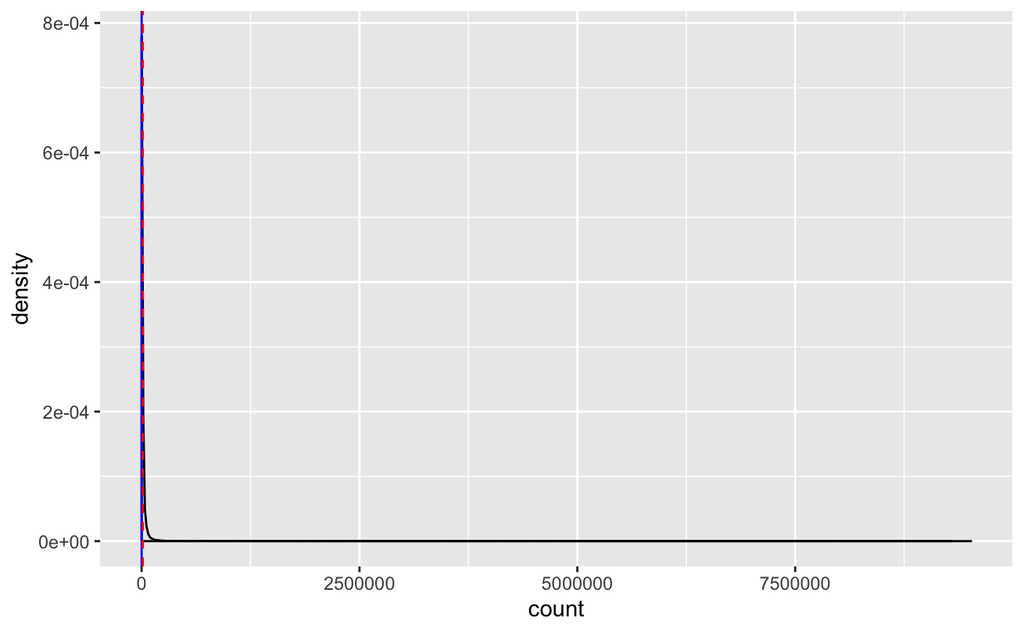

```r
# Let's take a look at the distribution of counts first

# Sum up the counts for each gene -- which means we want the sum of counts for
# each row as the rows represent gene data and the columns represent sample data
# in our dataset
count_sums <- data.frame(count = rowSums(counts(dds)))

# Create a density plot using the sums
ggplot2::ggplot(count_sums, ggplot2::aes(x = count)) +
  ggplot2::geom_density() +
  ggplot2::geom_vline(ggplot2::aes(xintercept = 10), # This line represents the current cutoff of 10
    color = "blue",
    linetype = "solid"
  ) +
  ggplot2::geom_vline(ggplot2::aes(xintercept = mean(count)), # This line represents the mean count value
    color = "red",
    linetype = "dashed"
  )
```

It appears that our arbitrary cutoff of 10 (the solid blue line) is a decent cutoff to make here as it seems to be just about inline with the mean counts value (the red dashed line) and retains the data points that are not in the majority and therefore may hold significance.

```r
# Define a minimum counts cutoff and filter `DESeqDataSet` object to include
# only rows that have counts above the cutoff
genes_to_keep <- rowSums(counts(dds)) >= 10
dds <- dds[genes_to_keep, ]
```

### 0.3.3 Perform DESeq2 normalization

```r
# Normalize the data in the `DESeqDataSet` object using the
# `rlog` function from the `DESEq2` R package
dds_norm <- rlog(dds)
```

[output not shown]

### 0.3.4 Choose genes of interest

Although you may want to create a heatmap including all of the genes in the set, alternatively, the heatmap could be created using only genes of interest. For this example, we will sort genes by variance, but there are many alternative criterion by which you may want to sort your genes *eg* fold change, t-statistic, membership to a particular gene ontology, so on.

```r
# Calculate the variance for each gene
variances <- apply(assay(dds_norm), 1, var)

# Determine the upper quartile variance cutoff value
upper_var <- quantile(variances, 0.75)

# Subset the data choosing only genes whose variances are in the upper quartile
df_by_var <- data.frame(assay(dds_norm)) %>%
  dplyr::filter(variances > upper_var)
```

### 0.3.5 Create a heatmap

To further customize the heatmap, see a vignette for a guide at this [link](https://slowkow.com/notes/pheatmap-tutorial/).

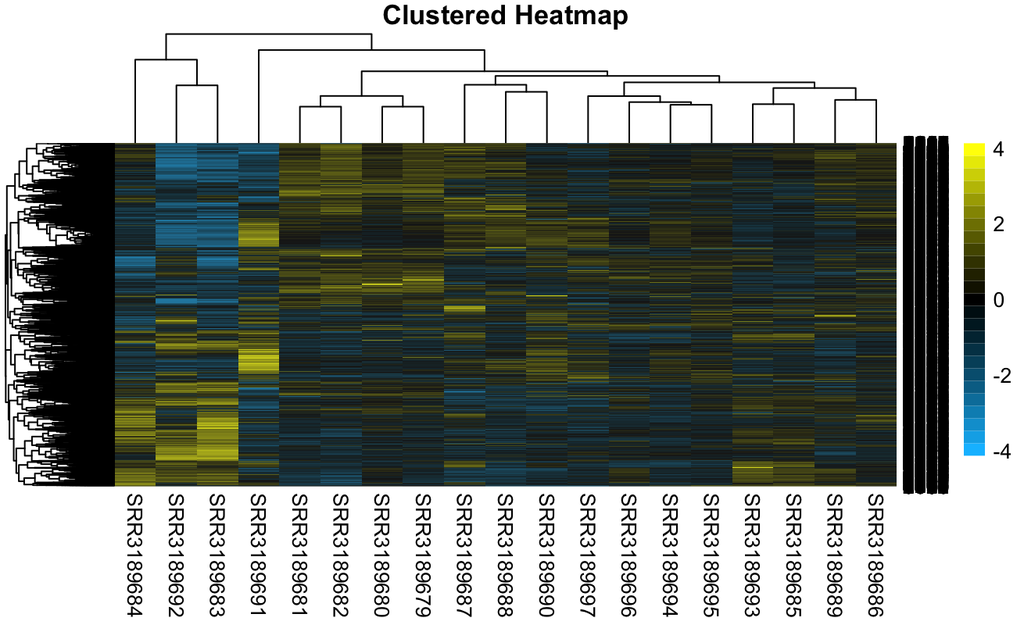

```r
# Create and store the technical replicates heatmap object
pheatmap <-
  pheatmap(
    df_by_var,
    cluster_rows = TRUE, # We want to cluster the heatmap by rows (genes in this case)
    cluster_cols = TRUE, # We also want to cluster the heatmap by columns (samples in this case)
    main = "Clustered Heatmap",
    colorRampPalette(c(
      "deepskyblue",
      "black",
      "yellow"
    ))(25
    ),
    scale = "row" # Scale values in the direction of genes (rows)
  )
```

We’ve created a heatmap but although our genes and samples are clustered, there is not much information that we can gather here because we did not provide the `pheatmap` function with annotation labels for our samples.

First let’s save our clustered heatmap.

#### 0.3.5.1 Save heatmap as a png

You can easily switch this to save to a jpeg or tiff by changing the function and file name within the function to the respective file suffix.

```r
# Open a png file
png(file.path(
  plots_dir,
  "HeatmapSRP070849_clustered.png" # Replace file name with a relevant output plot name
))

# Print your heatmap
pheatmap

# Close the png file:
dev.off()
```

Now, let’s add some annotation bars to our heatmap.

### 0.3.6 Prepare metadata for annotation

We are going to manipulate the metadata and add variables with the information that we would like to use to annotate the heatmap.

```r
# Let's prepare the annotation data.frame for the uncollapsed `DESeqData` set
# object which will be used to create the technical replicates heatmap
annotation_df <- metadata %>%
  # Create a variable to store the cancer type information
  dplyr::mutate(
    cancer_type = dplyr::case_when(
      startsWith(refinebio_title, "TET2") ~ "TET2",
      startsWith(refinebio_title, "IDH2") ~ "IDH2",
      startsWith(refinebio_title, "WT") ~ "WT",
      TRUE ~ "unknown"
    )
  ) %>%
  # We want to select the variables that we want for annotating the technical
  # replicates heatmap
  dplyr::select(
    refinebio_accession_code,
    cancer_type,
    refinebio_treatment
  ) %>%
  # The `pheatmap` function requires that the rownames of our annotation object
  # matches the column names of our `DESeaDataSet` object
  tibble::column_to_rownames("refinebio_accession_code")
```

#### 0.3.6.1 Create annotated heatmap

You can create an annotated heatmap by providing our annotation object to the `annotation_col` argument of the `pheatmap` function.

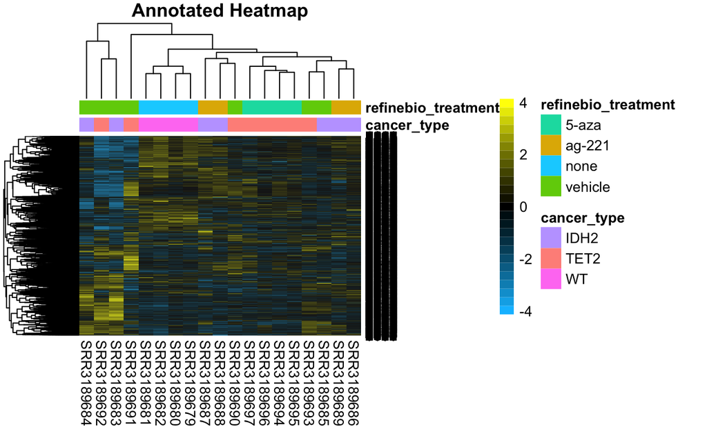

```r
# Create and store the annotated heatmap object
pheatmap_annotated <-
  pheatmap(
    df_by_var,
    cluster_rows = TRUE,
    cluster_cols = TRUE,
    annotation_col = annotation_df,
    main = "Annotated Heatmap",
    colorRampPalette(c(
      "deepskyblue",
      "black",
      "yellow"
    ))(25
    ),
    scale = "row" # Scale values in the direction of genes (rows)
  )
```

Now that we have annotation bars on our heatmap, we have a better idea of the sample variable groups that appear to cluster together.

Let’s save our annotated heatmap.

#### 0.3.6.2 Save annotated heatmap as a png

You can easily switch this to save to a jpeg or tiff by changing the function and file name within the function to the respective file suffix.

```r
# Open a png file
png(file.path(
  plots_dir,
  "HeatmapSRP070849_annotated.png" # Replace file name with a relevant output plot name
))

# Print your heatmap
pheatmap_annotated

# Close the png file:
dev.off()
```